# Start codon context for Candida Albicans

Edward Wallace, ewjwallace@gmail.com

16 Jan 2019

# Summary

This presents the analysis of Candida Albicans SC5314 start codon usage and context. This uses the C. albicans translation estimates from Nuzzey 2014.

# Here we go

## Expression: RNA abundance and ribosome-protected-fragments

### Load expression data

```
## # A tibble: 6,156 x 8
##    Gene          WTA1   WTA2    WTB WTARNA WTBRNA    RPF    RNA
##    <chr>        <dbl>  <dbl>  <dbl>  <dbl>  <dbl>  <dbl>  <dbl>
##  1 C3_06870W_A 30079. 30492. 10395  17620.  3915. 20340. 10767.
##  2 C1_08380W_A 17353. 17581. 20404. 10665. 10712. 18936. 10688.
##  3 C2_08370C_A 17241  17473. 20305  11100. 11102. 18831. 11101.
##  4 C4_02370C_A 13666. 14222. 14462.  3775.  4247. 14203.  4011.
##  5 C5_05050W_A 17301  16869.  3246. 16152.  1766. 10165.  8959.
##  6 C1_08500C_A 12486. 12714.  5505.  9001.  2281.  9053.  5641.
##  7 C4_06570C_A 14689. 14523.  2371. 10084.  1666.  8488.  5875.
##  8 C2_01610C_A  6492.  6550.  9310.  4549.  4589.  7915.  4569
##  9 C4_01750C_A 12265  12143.  3465. 11072.  2298.  7834.  6685.
## 10 C1_06580W_A  6190.  6127   8925.  6836.  8435   7542.  7635.
## # ... with 6,146 more rows
```

### Ribosome occupancy mostly tracks RNA abundance

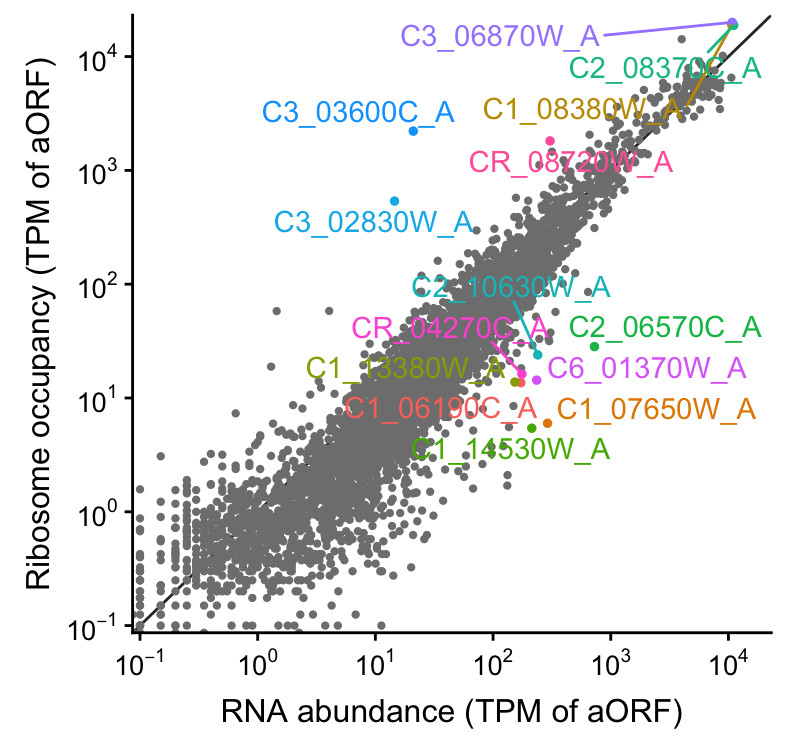

## ATG Context

### Load context data

```
## # A tibble: 6,184 x 19
##    Gene  aATG.context aATG.pos d1.context d1.posTSS d1.posATG d1.frame
##    <chr> <chr>           <dbl> <chr>          <dbl>     <dbl>    <dbl>
##  1 C1_0… ACAATTTTCAC…        1 TGACCTCGT…        14        13        1
##  2 C1_0… ACAGCGTTGGA…        1 AAGGGATTG…        47        46        1
##  3 C1_0… TCCCAAATCGT…        1 tcgttATGT…         8         7        1
##  4 C1_0… TTTCCCCCCAC…        1 GAAAACAAA…       104       103        1
##  5 C1_0… CACACAACTGT…        1 TAATTAATA…       101       100        1
##  6 C1_0… CCAGCAATGTC…        1 CAGAGTTGT…        50        49        1
##  7 C1_0… AACCCACCATC…        1 AATTGTGGC…       185       184        1
##  8 C1_0… TGGTAAGGGTG…        1 AGGAGTTGA…        17        16        1
##  9 C1_0… GGTGGAAAGTT…        1 AATCTTTTT…        63        62        2
## 10 C1_0… CATTGGTGGGC…        1 TGTTCCACA…        61        60        0
## # ... with 6,174 more rows, and 12 more variables: d2.context <chr>,
## #   d2.posTSS <dbl>, d2.posATG <dbl>, d2.frame <dbl>, u1.context <lgl>,
## #   u1.posTSS <chr>, u1.posATG <chr>, u1.frame <chr>, u2.context <chr>,
## #   u2.posTSS <chr>, u2.posATG <chr>, u2.frame <chr>
```

### Annotated ATGs have a Kozak consensus sequence

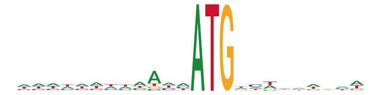

### Highly translated Annotated ATGs have a Kozak consensus sequence

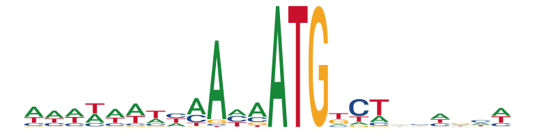

[figure not shown]

### Cytoplasmic Ribosome Annotated ATGs

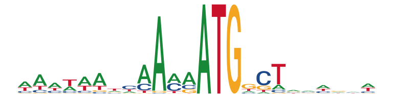

[figure not shown]

### Almost all cytoribo genes are highly translated

Venn diagram

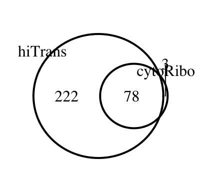

### Downstream ATGs don’t have a consensus

First downstream ATG

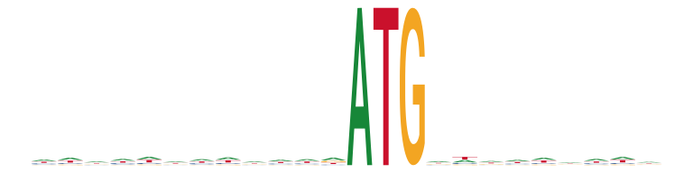

### Downstream ATGs in frame and highly translated don’t have a consensus

Except for 3rd-codon-position bias.

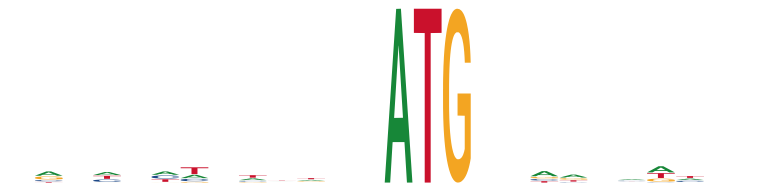

## Calculate Information content and scores of consensus motif

### Calculate a wide and a narrow consensus sequence

Calculate motif score against the position weight matrix (pwm) for both **narrow** (-4 from ATG through to ATG) and **wide** (-10 from ATG) kozak consensus motif. These motifs are taken from the top 5% highly translated genes.

### Estimate the information content

Using the sequence logo, details on https://en.wikipedia.org/wiki/Sequence_logo

```
## # A tibble: 6 x 4
##   Genes    ATG   Width  Infon
##   <chr>    <chr> <chr>  <dbl>
## 1 All      aATG  narrow 1.03
## 2 HiTrans  aATG  narrow 2.60
## 3 CytoRibo aATG  narrow 3.19
## 4 All      d1ATG narrow 0.310
## 5 HiTrans  d1ATG narrow 0.407
## 6 CytoRibo d1ATG narrow 0.462
```

### Estimate information content per base across start context

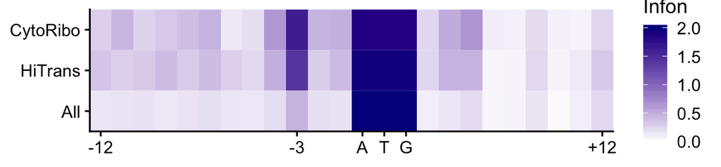

### Calculate scores of aATG, dATG, uATG against Kozak consensus

We calculate scores using Biostrings::PWMscoreStartingAt.

The best description I could find of this method is: https://support.bioconductor.org/p/61520/

It is just the sum of the matrix product of the PWM with the sequence.

Write scores to file *scores_kozak_Ca.txt*.

```
## # A tibble: 6,184 x 7
##    Gene  aATG.scorekn d1.scorekn aATG.scorekw d1.scorekw  d1vsan    d1vsaw
##    <chr>        <dbl>      <dbl>        <dbl>      <dbl>   <dbl>     <dbl>
##  1 C1_0…        0.925      0.831        0.923      0.757 -0.0933  -0.166
##  2 C1_0…        0.775      0.825        0.709      0.716  0.0503   0.00737
##  3 C1_0…        0.821      0.760        0.819     NA     -0.0610  NA
##  4 C1_0…        0.943      0.910        0.851      0.882 -0.0334   0.0316
##  5 C1_0…        0.825      0.917        0.820      0.920  0.0920   0.100
##  6 C1_0…        0.759      0.700        0.733      0.633 -0.0598  -0.101
##  7 C1_0…        0.877      0.854        0.824      0.747 -0.0234  -0.0777
##  8 C1_0…        0.659      0.867        0.622      0.751  0.207    0.128
##  9 C1_0…        0.752      0.902        0.692      0.882  0.150    0.190
## 10 C1_0…        0.824      0.848        0.731      0.818  0.0247   0.0876
## # ... with 6,174 more rows
```

### Plot against narrow consensus (-4 to ATG)

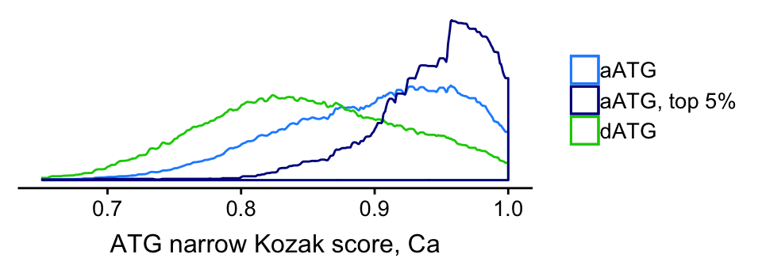

### Plot against wide consensus (-10 to ATG)

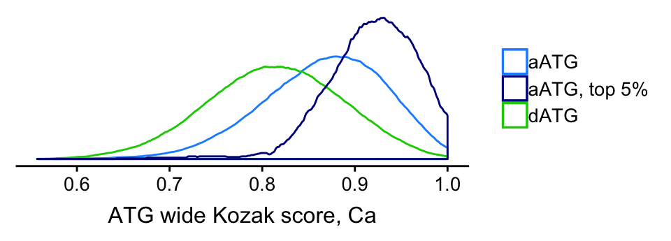

## Mutual information of different positions around ATG

### For all annotated genes

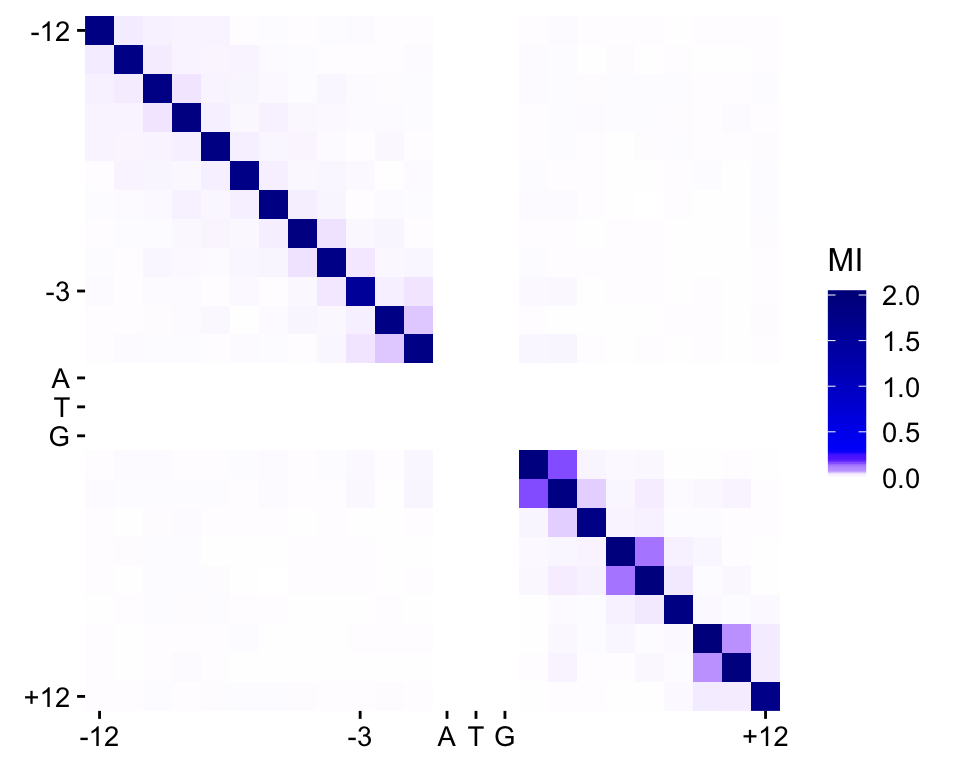

### For highly translated genes

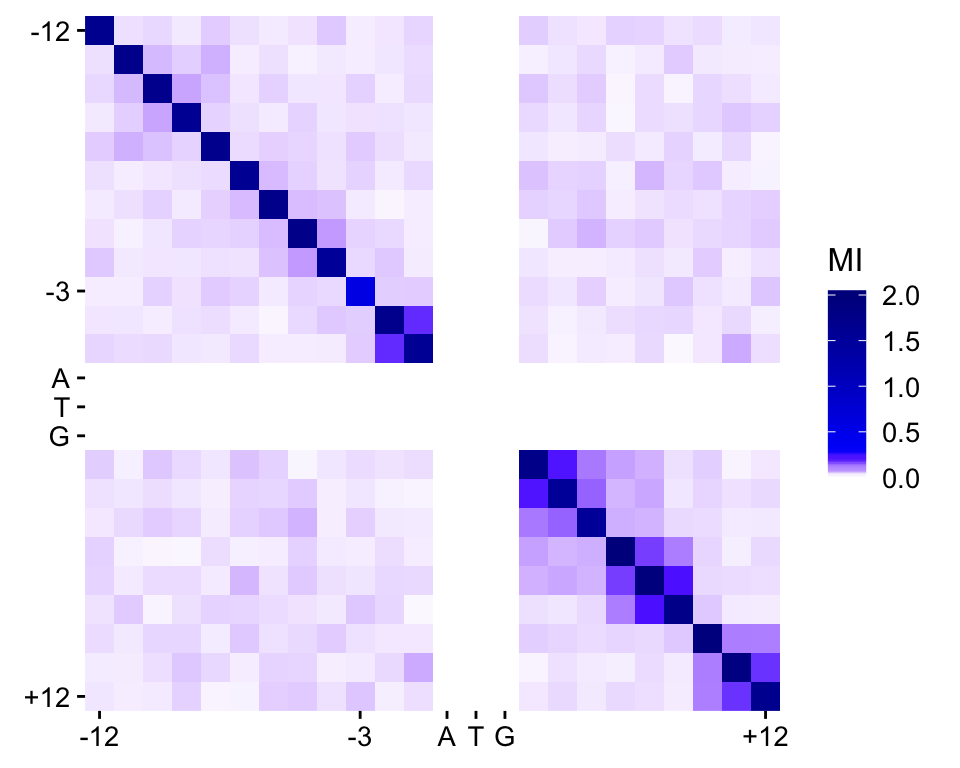

### For cytoplasmic ribosomal proteins

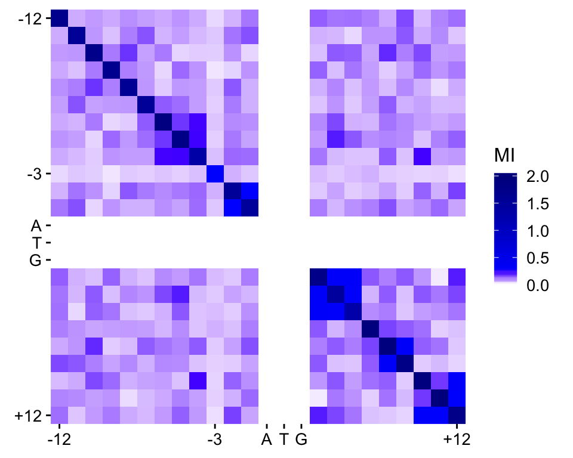

### What is the -2 correlation in cyto ribo genes?

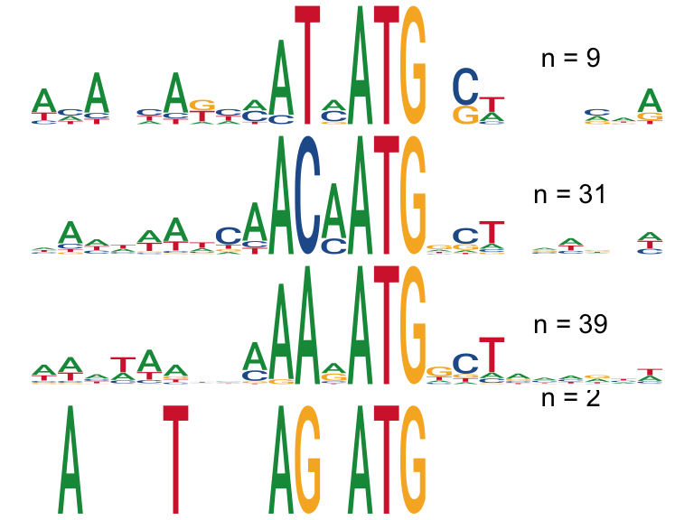

There are definitely correlations there.

### What about the -4 correlation in cyto ribo genes?

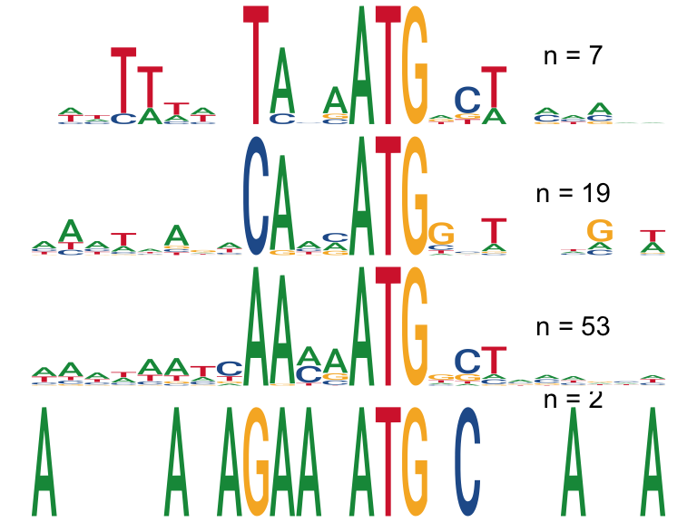

Weaker there.

## Compare aATG and dATG context by gene

### Most dATG scores are less than aATG scores

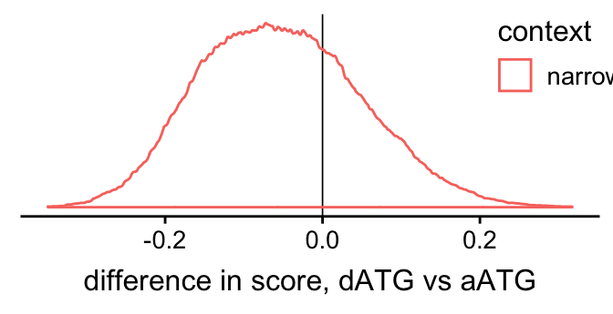

### For highly translated genes, most dATG narrow scores are much less than aATG

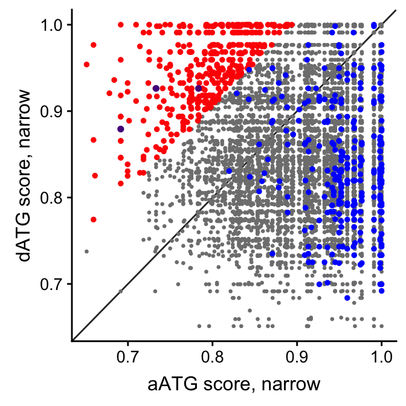

Red: high dATG vs aATG **Kozak** score. Blue: highly translated. Purple: both.

### Small negative correlation between dATG and aATG score narrow

R = -0.035

### For highly translated genes, most dATG wide scores are much less than aATG

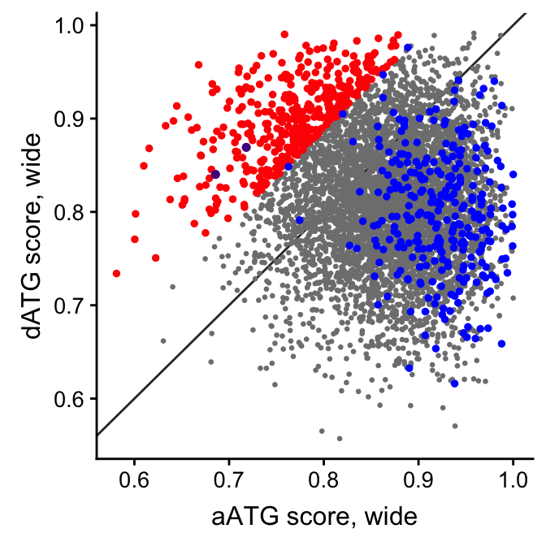

Red: high dATG vs aATG **Kozak** score. Blue: highly translated. Purple: both.

### Small negative correlation between dATG and aATG score wide

R = -0.045

## Genes with unusual dATG vs aATG score

### Genelist with unusual dATG vs aATG narrow score

Those genes are in this list:

```
## # A tibble: 400 x 3
##    Gene        aATG.scorekn d1.scorekn
##    <chr>              <dbl>      <dbl>
##  1 C4_03620C_A        0.659      0.977
##  2 C5_00840W_A        0.691      1.000
##  3 C3_02860W_A        0.651      0.954
##  4 C2_09260C_A        0.710      1.000
##  5 C3_03790W_A        0.725      1.000
##  6 C3_04120C_A        0.718      0.991
##  7 C6_02410W_A        0.691      0.959
##  8 C5_02090W_A        0.725      0.991
##  9 C3_06640W_A        0.734      0.998
## 10 C6_03510C_A        0.738      0.998
## # ... with 390 more rows
```

### Of which, highly translated:

```
## # A tibble: 3 x 5
##   Gene        aATG.scorekn d1.scorekn d1.frame d1.posATG
##   <chr>              <dbl>      <dbl>    <dbl>     <dbl>
## 1 C4_01710C_A        0.733      0.926        0        39
## 2 C5_04090C_A        0.691      0.879        1       103
## 3 C4_07180W_A        0.783      0.926        0       126
```

### dATG in frame with ATG, narrow

Files with high difference in narrow score, filtered for top 50% by mRNA abundance, in frame.

Saved to *dvsaATG_highdiffn_inframe_Ca.txt*.

```
## # A tibble: 52 x 3
##    Gene        aATG.scorekn d1.scorekn
##    <chr>              <dbl>      <dbl>
##  1 C5_00840W_A        0.691      1.000
##  2 C2_09260C_A        0.710      1.000
##  3 C3_03790W_A        0.725      1.000
##  4 C6_02410W_A        0.691      0.959
##  5 C1_08060W_A        0.750      1.000
##  6 C1_07700C_A        0.691      0.918
##  7 C1_00490C_A        0.774      0.998
##  8 C4_02340W_A        0.774      0.998
##  9 C2_10270W_A        0.738      0.959
## 10 C1_01040W_A        0.750      0.968
## # ... with 42 more rows
```

- C5_00840W_A, RNA transcription and export complex, TEX1 / YNL253W ortholog

See more below.

### dATG out of frame with ATG, narrow

Files with high difference in narrow score, filtered for top 50% by mRNA abundance, out of frame.

Saved to *dvsaATG_highdiffn_outframe_Ca.txt*.

```
## # A tibble: 86 x 3
##    Gene        aATG.scorekn d1.scorekn
##    <chr>              <dbl>      <dbl>
##  1 C2_06190W_A        0.744      1.000
##  2 C1_04120C_A        0.725      0.968
##  3 C2_01510C_A        0.761      0.991
##  4 C3_06440W_A        0.759      0.977
##  5 C1_08490W_A        0.793      1.000
##  6 C1_00080C_A        0.659      0.867
##  7 CR_01820W_A        0.750      0.952
##  8 CR_05240C_A        0.710      0.912
##  9 C1_00370W_A        0.810      1.000
## 10 C2_00700W_A        0.811      1.000
## # ... with 76 more rows
```

### dATG in frame with ATG, wide

Files with high difference in wide score, filtered for top 50% by mRNA abundance, in frame.

Saved to *dvsaATG_highdiffw_inframe_Ca.txt*.

```
## # A tibble: 47 x 3
##    Gene        aATG.scorekw d1.scorekw
##    <chr>              <dbl>      <dbl>
##  1 CR_09580C_A        0.682      0.937
##  2 C4_02340W_A        0.759      0.990
##  3 C3_03790W_A        0.729      0.957
##  4 C6_03820C_A        0.711      0.931
##  5 C1_00810W_A        0.713      0.927
##  6 C2_09260C_A        0.711      0.909
##  7 C1_00490C_A        0.775      0.968
##  8 C6_02350C_A        0.670      0.860
##  9 C1_05300C_A        0.730      0.915
## 10 C3_03940C_A        0.793      0.974
## # ... with 37 more rows
```

### dATG out of frame with ATG, wide

Files with high difference in wide score, filtered for top 50% by mRNA abundance, out of frame.

Saved to *dvsaATG_highdiffw_outframe_Ca.txt*.

```
## # A tibble: 111 x 3
##    Gene        aATG.scorekw d1.scorekw
##    <chr>              <dbl>      <dbl>
##  1 CR_01820W_A        0.711      0.954
##  2 CR_00410W_A        0.734      0.967
##  3 C1_04120C_A        0.698      0.911
##  4 C1_14480W_A        0.645      0.836
##  5 C1_00370W_A        0.785      0.972
##  6 C2_01510C_A        0.761      0.947
##  7 C4_02950C_A        0.761      0.942
##  8 C3_05550C_A        0.776      0.955
##  9 CR_08040W_A        0.720      0.895
## 10 C7_00060C_A        0.810      0.976
## # ... with 101 more rows
```

## Compare score difference to localization predictions

### Load predictions from mitofates

In input file *CAlbi_mitofates.txt*.

### Ca Genes with high dATG vs aATG score might be enriched in mitochondrial presequences?

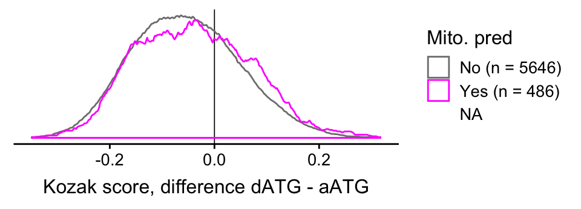

### Correlations between d1 score, d1 frame, and localization

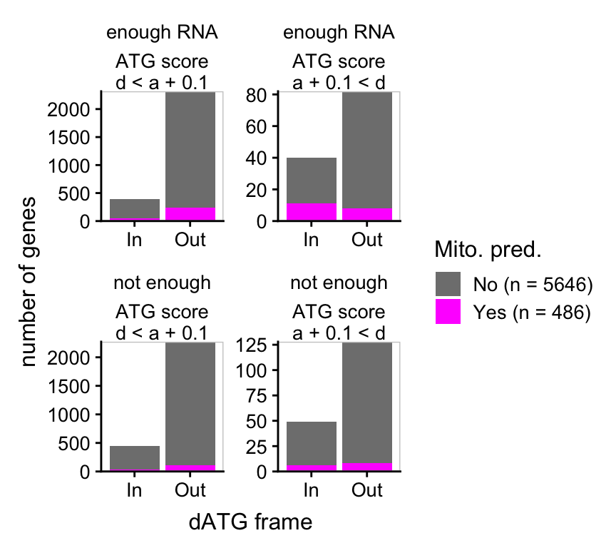

### Count dATG vs ATG score, d1 frame, mito pre, enough RNA

```
## # A tibble: 16 x 5
## # Groups:   enoughR, d1vsaw0p1, d1.framefac [?]
##    enoughR d1vsaw0p1 d1.framefac Pred_preseq     n
##    <fct>   <fct>     <fct>       <fct>       <int>
##  1 Yes     d1lo      In          No            350
##  2 Yes     d1lo      In          Yes            44
##  3 Yes     d1lo      Out         No           2078
##  4 Yes     d1lo      Out         Yes           240
##  5 Yes     d1hi      In          No             29
##  6 Yes     d1hi      In          Yes            11
##  7 Yes     d1hi      Out         No             74
##  8 Yes     d1hi      Out         Yes             8
##  9 No      d1lo      In          No            422
## 10 No      d1lo      In          Yes            30
## 11 No      d1lo      Out         No           2159
## 12 No      d1lo      Out         Yes           114
## 13 No      d1hi      In          No             43
## 14 No      d1hi      In          Yes             6
## 15 No      d1hi      Out         No            120
## 16 No      d1hi      Out         Yes             8
```

### Ca mito-localized genes also do not have a distinctive aATG context

Although the +5 T is striking.

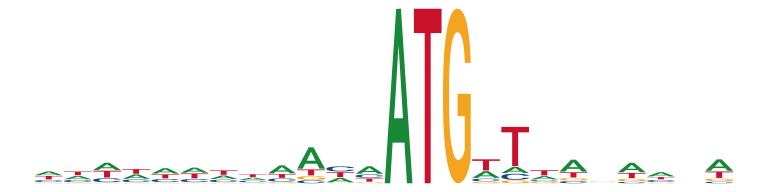

## Genes with unusual dATG vs aATG narrow score AND predicted mito loc

Those genes are in this list:

```
## # A tibble: 44 x 7
##    Gene        aATG.scorekn d1.scorekn d1.frame d1.posATG    RPF   RNA
##    <chr>              <dbl>      <dbl>    <dbl>     <dbl>  <dbl> <dbl>
##  1 C2_09260C_A        0.710      1.000        0        39  52.9   76.6
##  2 C6_02410W_A        0.691      0.959        0        24  31.7   59.7
##  3 C2_06190W_A        0.744      1.000        2       113  70.3  108.
##  4 C1_08060W_A        0.750      1.000        0        72 294.   424.
##  5 C1_00490C_A        0.774      0.998        0        45 370    464.
##  6 C1_03320C_A        0.700      0.922        0        69   6.22   7.1
##  7 C2_10270W_A        0.738      0.959        0        36  22.2   46.2
##  8 C1_01040W_A        0.750      0.968        0        39  47.2   42
##  9 C2_07940C_A        0.800      0.998        0       213   8.25  33.2
## 10 C1_00370W_A        0.810      1.000        1        43  24.7   37.4
## 11 C6_03720W_A        0.734      0.917        0        24 133.   155.
## 12 CR_04590C_A        0.819      1.000        0        66 227.   222.
## 13 CR_04300W_A        0.801      0.977        0        24  66.1   79.2
## 14 C6_00490W_A        0.838      1.000        2       104   3.58  10.6
## 15 C2_02980C_A        0.758      0.918        1       229  15.9   32.0
## 16 C5_01520C_A        0.783      0.940        0        75 110.   125.
## 17 C1_02960C_A        0.811      0.968        1       226   4.6   17.7
## 18 CR_10010C_A        0.765      0.918        2        50  43.5   69.2
## 19 C3_02270W_A        0.805      0.954        0         9  72.4   75.4
## 20 C2_06640C_A        0.775      0.922        0       114 106.   150.
## 21 C2_05470W_A        0.852      1.000        1       130 115.   128.
## 22 C6_03820C_A        0.775      0.917        0        42  21.1   55.4
## 23 C6_02860W_A        0.775      0.917        0        72  12.8   18.6
## 24 C6_00390W_A        0.773      0.914        0        63  18.4   17.9
## 25 CR_01550C_A        0.820      0.959        0        30  14.8   38.0
## 26 C4_06430C_A        0.765      0.905        1       103   7.08  14
## # ... with 18 more rows
```

Only some have in-frame ATG.

- C2_06190W_A / ILV1Putative threonine dehydratase; regulated by *Gcn4* and Gcn2; induced by amino acid starvation (3-AT);

### Some more decently-translated ones with in-frame aATG and mito. loc

```
## # A tibble: 18 x 7
##    Gene        aATG.scorekn d1.scorekn d1.frame d1.posATG   RPF   RNA
##    <chr>              <dbl>      <dbl>    <dbl>     <dbl> <dbl> <dbl>
##  1 C2_09260C_A        0.710      1.000        0        39  52.9  76.6
##  2 C6_02410W_A        0.691      0.959        0        24  31.7  59.7
##  3 C1_08060W_A        0.750      1.000        0        72 294.  424.
##  4 C1_00490C_A        0.774      0.998        0        45 370   464.
##  5 C2_10270W_A        0.738      0.959        0        36  22.2  46.2
##  6 C1_01040W_A        0.750      0.968        0        39  47.2  42
##  7 C6_03720W_A        0.734      0.917        0        24 133.  155.
##  8 CR_04590C_A        0.819      1.000        0        66 227.  222.
##  9 CR_04300W_A        0.801      0.977        0        24  66.1  79.2
## 10 C5_01520C_A        0.783      0.940        0        75 110.  125.
## 11 C3_02270W_A        0.805      0.954        0         9  72.4  75.4
## 12 C2_06640C_A        0.775      0.922        0       114 106.  150.
## 13 C6_03820C_A        0.775      0.917        0        42  21.1  55.4
## 14 C6_00390W_A        0.773      0.914        0        63  18.4  17.9
## 15 CR_01550C_A        0.820      0.959        0        30  14.8  38.0
## 16 C1_13030C_A        0.775      0.894        0        39  74.1 112.
## 17 C2_02640C_A        0.765      0.878        0        51  36.6  57.4
## 18 C2_02950W_A        0.765      0.878        0        51  37.0  59.6
```

- C2_09260C_A GLO2 hydroxyacylglutathione hydrolase, Scer has GLO2 (cyto) and GLO4 (mito) paralogs
- C1_00490C_A TTR1 Putative glutaredoxin, regulated by Gcn2 and Gcn4, Scer has GRX1 (cyto/nuc) and GRX2 (mito/cyto) paralogs
- C3_02270W_A conserved hypothetical protein with signal peptide, Scer MCO8 is found in mitochondria.
- C6_02410W_A, NAD(+) diphosphatase homolog, Scer NPY1 / YGL067W localizes to peroxisome and cytoplasm.
- C1_08060W_A OFR1 Protein involved in regulation of white-opaque switching
- CR_04300W_A tRNA (cytosine-5-)-methyltransferase, Scer homolog NCL1 is nuclear.
- CR_04590C_A PDX3 Pyridoxamine-phosphate oxidase
- C6_03720W_A ALA1 Alanyl-tRNA synthetase; translational regulation generates cytoplasmic and mitochondrial forms.
- C5_01520C_A GLR1 Glutathione reductase
- C2_10270W_A PUS7 Pseudouridine synthase
- C1_01040W_A Methionine-R-sulfoxide reductase, Scer homolog MXR2 is mitochondrial.
- CR_01550C_A 3’–> 5’ exonuclease and endonuclease
- C6_03820C_A conserved protein of unknown function with homology to probable FAD synthase and Molybdenum cofactor biosynth proteins??
- C2_06640C_A tRNA-Val synthetase VAS1
- C6_00390W_A tRNA-Serine synthetase, there is another paralog C3_02780W_A, homology to cyto SES1, and a mito DIA4 homolog.

Several of these are conserved (ALA1, VAS1, PUS7, GLOs, GLR)!

Back to table of contents